# Aaron Judge's Historic Season and The Evolution of The Power Hitter

### Data Analysis By Russ Steil

[figure not shown]

## Introduction

This season (2022), the MLB saw one of the most improbable performances from a batter then it had in its entire history. Aaron Judge of the New York Yankees blasted an astounding 62 home runs. This broke the previous record for home runs in a season in the American League, held by Roger Maris. But just how improbable of a season was this for Judge? To see the improbability of this season we'll need to look at how baseball has changed for hitters over the last decade. We'll look at the changes in hitting statistics from 2008 to 2019. In 2019, it was speculated that the MLB was juicing balls to provide hitters with more of an advantage. This is reflected by the hitting statistics from that year. However, the MLB deadened the balls before the 2022 season making hitting statistics fall dramatically. This made it much harder for hitters to hit home runs during the 2022 season. All hitters except, Aaron Judge.

## Data Importing and Cleaning

### Libraries

This data analysis utilized the Pandas, NumPy, Scipy, Matplotlib, Files, and IO libraries. Files and IO were used to import the three datasets. Pandas dataframes were utilizied as the primary structure for organizing the data. Numpy and Scipy were used for statistical analysis. Matplotlib was used for data visualization.

```python
import pandas as pd
import numpy as np
%matplotlib inline
import matplotlib.pyplot as plt
from google.colab import files
from scipy import stats
import io
```

### Loading and Cleaning Data

This next large section of code is the loading and cleaning/standardizing of all of the datasets that were used in this project. The first part is uploading a file of the data and then reading it in as a csv. From there the data was cleaned to only use statistics that were in all three of the datasets. Then any players that had less than 200 at bats were removed. This was done to make sure that the hitting statistics that were being used were from people who had a significant amount of plate appearaces. Another part of standardizing this data was renaming two of the columns in the 2019 and 2022 set to have the same name as the corresponding columns in the 2008 set.

### 2008 Loading and Cleaning

```python
uploaded = files.upload()
```

Upload widget is only available when the cell has been executed in the current browser session. Please rerun this cell to enable.

```
Saving MLB2008.csv to MLB2008.csv
```

```python
df_2008 = pd.read_csv(io.BytesIO(uploaded['MLB2008.csv']))

x_columns = ["PLAYER","POS", "G", "AB", "H", "2B", "3B", "HR", "RBI", "SO", "AVG", "SLG", "R"]
filtered_data_2008 = df_2008[x_columns]
set_2008 = filtered_data_2008[df_2008.AB > 200]

set_2008.head()
```

|  | PLAYER | POS | G | AB | H | 2B | 3B | HR | RBI | SO | AVG | SLG | R |
| --- | --- | --- | --- | --- | --- | --- | --- | --- | --- | --- | --- | --- | --- |
| 0 | Gregg Zaun | 2 | 85 | 245 | 58 | 12 | 0 | 6 | 30 | 38 | 0.237 | 0.359 | 29 |
| 3 | Corey Patterson | 8 | 123 | 366 | 75 | 17 | 2 | 10 | 34 | 57 | 0.205 | 0.344 | 46 |
| 4 | Rod Barajas | 2 | 100 | 349 | 87 | 23 | 0 | 11 | 49 | 61 | 0.249 | 0.410 | 44 |
| 5 | Rich Aurilia | 3 | 134 | 407 | 115 | 21 | 1 | 10 | 52 | 56 | 0.283 | 0.413 | 33 |
| 6 | Yorvit Torrealba | 2 | 68 | 236 | 58 | 17 | 0 | 6 | 31 | 44 | 0.246 | 0.394 | 19 |

### 2019 Loading and Cleaning

```python
uploaded = files.upload()
```

Upload widget is only available when the cell has been executed in the current browser session. Please rerun this cell to enable.

```
Saving MLB2019.csv to MLB2019.csv
```

```python
new_df_2019 = pd.read_csv(io.BytesIO(uploaded['MLB2019.csv']))

x_columns = ["Player","Pos","G", "AB", "H", "2B", "3B", "HR", "RBI", "SO", "AVG", "SLG", "R"]
filtered_new_data = new_df_2019[x_columns]
filtered_new_data = filtered_new_data.rename({"Pos" : "POS", "Player" : "PLAYER"}, axis = "columns")
set_2019 = filtered_new_data[filtered_new_data.AB > 200]

set_2019.head()
```

|  | PLAYER | POS | G | AB | H | 2B | 3B | HR | RBI | SO | AVG | SLG | R |
| --- | --- | --- | --- | --- | --- | --- | --- | --- | --- | --- | --- | --- | --- |
| 0 | Whit Merrifield | 2B | 162 | 681 | 206 | 41 | 10 | 16 | 74 | 126 | 0.302 | 0.463 | 105 |
| 1 | Marcus Semien | 2B | 162 | 657 | 187 | 43 | 7 | 33 | 92 | 102 | 0.285 | 0.522 | 123 |
| 2 | Rafael Devers | 3B | 156 | 647 | 201 | 54 | 4 | 32 | 115 | 119 | 0.311 | 0.555 | 129 |
| 3 | Jonathan Villar | 3B | 162 | 642 | 176 | 33 | 5 | 24 | 73 | 176 | 0.274 | 0.453 | 111 |
| 4 | Ozzie Albies | 2B | 160 | 640 | 189 | 43 | 8 | 24 | 86 | 112 | 0.295 | 0.500 | 102 |

### 2022 Loading and Cleaning

```python
uploaded = files.upload()
```

Upload widget is only available when the cell has been executed in the current browser session. Please rerun this cell to enable.

```
Saving MLB2022.csv to MLB2022.csv
```

```python
new_df_2022 = pd.read_csv(io.BytesIO(uploaded['MLB2022.csv']))

x_columns = ["Player","Pos","G", "AB", "H", "2B", "3B", "HR", "RBI", "SO", "AVG", "SLG", "R"]
filtered_new_data_2022 = new_df_2022[x_columns]
filtered_new_data_2022 = filtered_new_data_2022.rename({"Pos" : "POS", "Player" : "PLAYER"}, axis = "columns")
set_2022 = filtered_new_data_2022[filtered_new_data_2022.AB > 200]

set_2022.head()
```

|  | PLAYER | POS | G | AB | H | 2B | 3B | HR | RBI | SO | AVG | SLG | R |
| --- | --- | --- | --- | --- | --- | --- | --- | --- | --- | --- | --- | --- | --- |
| 0 | Marcus Semien | 2B | 161 | 657 | 163 | 31 | 5 | 26 | 83 | 120 | 0.248 | 0.429 | 101 |
| 1 | Trea Turner | SS | 160 | 652 | 194 | 39 | 4 | 21 | 100 | 131 | 0.298 | 0.466 | 101 |
| 2 | Bo Bichette | SS | 159 | 652 | 189 | 43 | 1 | 24 | 93 | 155 | 0.290 | 0.469 | 91 |
| 3 | Dansby Swanson | SS | 162 | 640 | 177 | 32 | 1 | 25 | 96 | 182 | 0.277 | 0.447 | 99 |
| 4 | Vladimir Guerrero | 1B | 160 | 638 | 175 | 35 | 0 | 32 | 97 | 116 | 0.274 | 0.480 | 90 |

## Statistical Analysis

### Home Run Stats

```python
# HR STATISTICS: HOW AARON JUDGES 2022 SEASON COMPARES

HR_array_2008 = np.array(set_2008['HR'])
print("Home Run Leader: Ryan Howard with", max(set_2008.HR))
print("2008 MLB Median # of Home Runs:", "%.1f" % np.median(HR_array_2008))
print("2008 MLB Average # of Home Runs:", "%.1f" % HR_array_2008.mean())
print("std:", "%.3f" % HR_array_2008.std(),"\n")


HR_array_2019 = np.array(set_2019['HR'])
print("Home Run Leader: Pete Alonso with", max(set_2019.HR))
print("2019 MLB Median # of Home Runs:", "%.1f" % np.median(HR_array_2019))
print("2019 MLB Average # of Home Runs:", "%.1f" % HR_array_2019.mean())
print("std:", "%.3f" % HR_array_2019.std(),"\n")


HR_array_2022 = np.array(set_2022['HR'])
print("Home Run Leader: Aaron Judge with", max(set_2022.HR))
print("2022 MLB Median # of Home Runs:", "%.1f" % np.median(HR_array_2022))
print("2022 MLB Average # of Home Runs:", "%.1f" % HR_array_2022.mean())
print("std:", "%.3f" % HR_array_2022.std(),"\n")
```

```
Home Run Leader: Ryan Howard with 48
2008 MLB Median # of Home Runs: 12.0
2008 MLB Average # of Home Runs: 14.1
std: 10.077

Home Run Leader: Pete Alonso with 53
2019 MLB Median # of Home Runs: 15.0
2019 MLB Average # of Home Runs: 17.5
std: 10.474

Home Run Leader: Aaron Judge with 62
2022 MLB Median # of Home Runs: 11.5
2022 MLB Average # of Home Runs: 13.3
std: 9.088
```

These stats showcase the median, average, standard deviation, and the maximum number of home runs from hitters across the 2008, 2019, and 2022 seasons. All three seasons had a standard deviation within roughly one home run of eachother, indicating that their home run data is similarly dispersed with 2022 having the most tightly dispersed with a STD of 9.088 and 2019 having the most widely dispersed with an STD of 10.474.

Regarding median and average; 2019 was the season with the highest average and median number of home runs by far with an average number of 17.5 home runs and a median number of 15.0. This is a staunch increase from the 2008 season which featured an average number of 14.1 home runs and a median of 12.0. This increase is a result of a shift in the game of baseball from a game focused on batting average and situational hitting to score runs toward a game that relies on the long ball to win.

However, despite this shift in theory the 2022 season had the lowest average and median home runs of all three seasons at 13.3 and 11.5 respectively. This decrease in power hitting is a shock for home run reliant baseball teams, whose scoring also decreased significantly from the 2019 season. This drop can be attributed to the MLB's implementation of "deadened" baseballs in the 2022 season that are softer than the baseballs used in 2019 and 2008 and therefore do not travel as far off the bat.

The deadened baseballs proved no match for Aaron Judge in 2022 when he hit a historic 62 home runs, squashing the previous American League record and placing him among the ranks of the steroid-era hitters Sammy Sosa (66), Mark McGwire (70), and Barry Bonds (73).

#### Home Run Plot

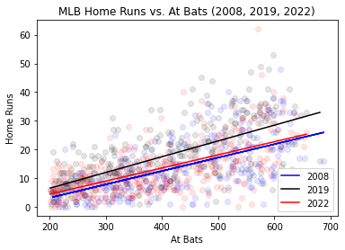

```python
#AB vs HR 2008, 2019, 2022

plt.scatter(set_2008.AB, set_2008.HR, color = "blue", alpha = 0.1)
HR_slope_2008, HR_yint_2008 = np.polyfit(set_2008.AB, set_2008.HR, 1)
plt.plot(set_2008.AB, HR_slope_2008*set_2008.AB+HR_yint_2008, color = "blue", label = "2008")

plt.scatter(set_2019.AB, set_2019.HR, color = "black", alpha = 0.1)
HR_slope_2019, HR_yint_2019 = np.polyfit(set_2019.AB, set_2019.HR, 1)
plt.plot(set_2019.AB, HR_slope_2019*set_2019.AB+HR_yint_2019, color = "black", label = "2019")

plt.scatter(set_2022.AB, set_2022.HR, color = "red", alpha = 0.1)
HR_slope_2022, HR_yint_2022 = np.polyfit(set_2022.AB, set_2022.HR, 1)
plt.plot(set_2022.AB, HR_slope_2022*set_2022.AB+HR_yint_2022, color = "red", label = "2022")

plt.xlabel("At Bats")
plt.ylabel("Home Runs")
plt.title("MLB Home Runs vs. At Bats (2008, 2019, 2022)")

plt.legend(loc = "lower right")
plt.show()
```

This scatter plot shows the home run changes over time. It is clear to see that there was a massive amount of home runs being hit in 2019 and then a sharp decrease to 2008 levels of home runs in 2022. Note also the outlier in the top right corner of the plot, Aaron Judge.

### Strikeout Stats

```python
# SO STATISTICS

SO_array_2008 = np.array(set_2008['SO'])
print("MLB Average Number of Strikeouts 2008","%.1f" % SO_array_2008.mean())
print("std","%.3f" % SO_array_2008.std())
print("MLB Median Number of Strikeouts 2008","%.1f" % np.median(SO_array_2008), "\n")

SO_array_2019 = np.array(set_2019['SO'])
print("MLB Average Number of Strikeouts 2019","%.1f" % SO_array_2019.mean())
print("std","%.3f" % SO_array_2019.std())
print("MLB Median Number of Strikeouts 2019","%.1f" % np.median(SO_array_2019), "\n")

SO_array_2022 = np.array(set_2022['SO'])
print("MLB Average Number of Strikeouts 2022","%.1f" % SO_array_2022.mean())
print("std","%.3f" % SO_array_2022.std())
print("MLB Median Number of Strikeouts 2022","%.1f" % np.median(SO_array_2022), "\n")

print("98th percentile of Strikeouts in 2022:", np.percentile(SO_array_2022, 98))
print("Aaron Judge Strikeouts 2022: 175")
```

```
MLB Average Number of Strikeouts 2008 78.1
std 34.052
MLB Median Number of Strikeouts 2008 71.0

MLB Average Number of Strikeouts 2019 97.0
std 34.977
MLB Median Number of Strikeouts 2019 94.0

MLB Average Number of Strikeouts 2022 94.5
std 33.543
MLB Median Number of Strikeouts 2022 92.0

98th percentile of Strikeouts in 2022: 170.0
Aaron Judge Strikeouts 2022: 175
```

The strikeout data also enscapulates the emergence of the long ball hitters in the MLB; with the median number of strikeouts jumping by 23 strikeouts from 2008 to 2019 (71.0 to 94.0 strikeouts) and decreasing slightly but remaining high in 2022 (92.0 strikeouts). This jump is also reflected in the averages.

The slight decrease in average number of strikeouts from 2019 to 2022 can be deemed insignificant since when a two tailed P score test is conducted on the change the result is a P value of 0.18 which is much greater than 0.05 and the T-statistic (1.329) is lesser than the T-critical value (1.967).

As far as Aaron Judge's stats go; in 2022 he had 175 strikeouts placing him in the 98th percentile for all 2022 hitters and fulfilling his status as the archetype of a "Swing For The Fences" type of hitter.

#### Strikeout Plot

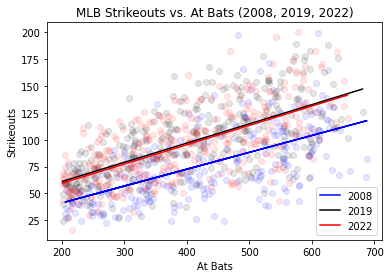

```python
#AB vs SO 2019, 2008, 2022

plt.scatter(set_2008.AB, set_2008.SO, color = "blue", alpha = 0.1)
SO_slope_2008, SO_yint_2008 = np.polyfit(set_2008.AB, set_2008.SO, 1)
plt.plot(set_2008.AB, SO_slope_2008*set_2008.AB+SO_yint_2008, color = "blue", label = "2008")

plt.scatter(set_2019.AB, set_2019.SO, color = "black", alpha = 0.1)
SO_slope_2019, SO_yint_2019 = np.polyfit(set_2019.AB, set_2019.SO, 1)
plt.plot(set_2019.AB, SO_slope_2019*set_2019.AB+SO_yint_2019, color = "black", label = "2019")

plt.scatter(set_2022.AB, set_2022.SO, color = "red", alpha = 0.1)
SO_slope_2022, SO_yint_2022 = np.polyfit(set_2022.AB, set_2022.SO, 1)
plt.plot(set_2022.AB, SO_slope_2022*set_2022.AB+SO_yint_2022, color = "red", label = "2022")

plt.xlabel("At Bats")
plt.ylabel("Strikeouts")
plt.title("MLB Strikeouts vs. At Bats (2008, 2019, 2022)")

plt.legend(loc = "lower right")
plt.show()
```

This scatter plot displays the number of strikeouts against at bats. As was noted before, the 2019 and 2022 strikeout numbers are relatively similar. However, both of these strikeout averages are much higher than what was seen in 2008.

#### Strikeout Hypothesis Test

```python
#Determining if drop from 2019 to 2022 in SO is significant
print("Two Tailed P Test on 2019 vs 2022 Strikeout Averages")

SO_2022_mean = SO_array_2022.mean()
SO_2019_mean = SO_array_2019.mean()

std_error_2019 = (SO_array_2019.std() / np.sqrt(len(SO_array_2019)))

t = abs(SO_2019_mean - SO_2022_mean) / std_error_2019
t_crit = stats.t.ppf(q = 0.975, df = (len(SO_array_2019) - 1))
print("T-Critical:", "%.3f" % t_crit)
print("T-Statistic:", "%.3f" % t)

p = 2*(1-stats.t.cdf(x=t, df = (len(SO_array_2019) - 1)))
print("P Value:", "%.2f" % p)
```

```
Two Tailed P Test on 2019 vs 2022 Strikeout Averages
T-Critical: 1.967
T-Statistic: 1.329
P Value: 0.18
```

### Batting Average Stats

```python
# AVG STATISTICS

AVG_array_2008 = np.array(set_2008['AVG'])
print("2008 MLB Total Battting Average:", "%.3f" % AVG_array_2008.mean(), "\n")

AVG_array_2019 = np.array(set_2019['AVG'])
print("2019 MLB Total Battting Average:", "%.3f" % AVG_array_2019.mean(), "\n")

AVG_array_2022 = np.array(set_2022['AVG'])
print("2022 MLB Total Battting Average:", "%.3f" % AVG_array_2022.mean(), "\n")

print("98th percentile for Batting average in 2022:", "%.3f" % np.percentile(AVG_array_2022, 98))
print("Aaron Judge Batting Average: 0.311")
```

```
2008 MLB Total Battting Average: 0.269

2019 MLB Total Battting Average: 0.258

2022 MLB Total Battting Average: 0.245

98th percentile for Batting average in 2022: 0.308
Aaron Judge Batting Average: 0.311
```

Despite his high number of strikeouts Aaron Judge still hit for an average of 0.311 in 2022, again placing him in the 98th percentile for 2022 but this time for a more positive stat.

#### Batting Average Plot

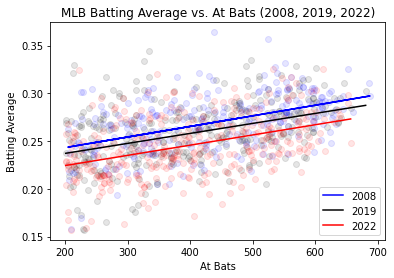

```python
#AB vs AVG 2008,2019, 2022

plt.scatter(set_2008.AB, set_2008.AVG, color = "blue", alpha = 0.1)
AVG_slope_2008, AVG_yint_2008 = np.polyfit(set_2008.AB, set_2008.AVG, 1)
plt.plot(set_2008.AB, AVG_slope_2008*set_2008.AB+AVG_yint_2008, color = "blue", label = "2008")

plt.scatter(set_2019.AB, set_2019.AVG, color = "black", alpha = 0.1)
AVG_slope_2019, AVG_yint_2019 = np.polyfit(set_2019.AB, set_2019.AVG, 1)
plt.plot(set_2019.AB, AVG_slope_2019*set_2019.AB+AVG_yint_2019, color = "black", label = "2019")

plt.scatter(set_2022.AB, set_2022.AVG, color = "red", alpha = 0.1)
AVG_slope_2022, AVG_yint_2022 = np.polyfit(set_2022.AB, set_2022.AVG, 1)
plt.plot(set_2022.AB, AVG_slope_2022*set_2022.AB+AVG_yint_2022, color = "red", label = "2022")

plt.xlabel("At Bats")
plt.ylabel("Batting Average")
plt.title("MLB Batting Average vs. At Bats (2008, 2019, 2022)")

plt.legend(loc = "lower right")
plt.show()
```

This plot displays the batting average of players against their at bats with lines of best fit.

## Plotting

### Histograms (2008-2019)

This first histogram displays the frequency in which people were hitting a certain number of home runs in both 2008 and 2019. One thing to notice is that the number of people that were hitting 20+ home runs in 2019 is much higher than in 2008. Another thing to notice is the frequency of people that were hitting between 0 and 5 homeruns. Almost double the amount of people hit between 0 and 5 homeruns in 2008 than in 2019. In summary, this graph shows that there were way more homeruns being hit in 2019 than in 2008.

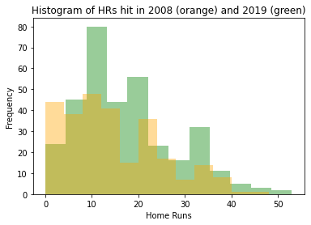

```python
plt.hist(set_2019.HR, bins = 12, color = "green", stacked = True, alpha = 0.4)
plt.hist(set_2008.HR, bins = 12, color = 'orange', stacked = True, alpha = 0.4)
plt.title("Histogram of HRs hit in 2008 (orange) and 2019 (green)")
plt.xlabel("Home Runs")
plt.ylabel("Frequency")
plt.show()
```

This histogram here shows the change in batting average from 2008 to 2019. As you can see, there is a much higher frequency of people with batting averages near .300 in 2008 than there is in 2019. There is also a much higher frequency of people with lower batting averages in 2019 than in 2008.

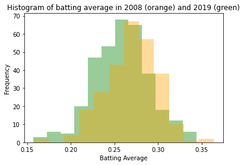

```python
plt.hist(set_2019.AVG, bins = 12, color = "green", stacked = True, alpha = 0.4)
plt.hist(set_2008.AVG, bins = 12, color = 'orange', stacked = True, alpha = 0.4)
plt.title("Histogram of batting average in 2008 (orange) and 2019 (green)")
plt.xlabel("Batting Average")
plt.ylabel("Frequency")
plt.show()
```

This histogram shows the number of hits in 2008 versus 2019. It is clear to see that there is a much higher frequency of people getting 150+ hits in 2008 then there is in 2019. Also there is a much higher frequency of people getting less than 50 hits in 2019 than there is in 2008.

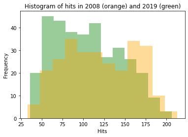

```python
plt.hist(set_2019.H, bins = 12, color = "green", stacked = True, alpha = 0.4)
plt.hist(set_2008.H, bins = 12, color = 'orange', stacked = True, alpha = 0.4)
plt.title("Histogram of hits in 2008 (orange) and 2019 (green)")
plt.xlabel("Hits")
plt.ylabel("Frequency")
plt.show()
```

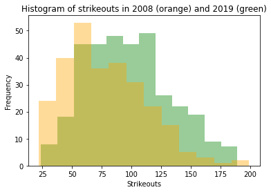

```python
plt.hist(set_2019.SO, bins = 12, color = "green", stacked = True, alpha = 0.4)
plt.hist(set_2008.SO, bins = 12, color = 'orange', stacked = True, alpha = 0.4)
plt.title("Histogram of strikeouts in 2008 (orange) and 2019 (green)")
plt.xlabel("Strikeouts")
plt.ylabel("Frequency")
plt.show()
```

### Histograms (2019-2022)

These next few plots are histograms that compare the data of the 2019 season to the data of the 2022 season. This first histogram here compares the home runs from the two seasons. The main thing to notice is the amount of players in 2019 that are hitting over 30 home runs versus the number of players from 2022 that are hitting over 30 home runs. What's worth noting is the outlier from 2022 who is at 60+ home runs. This of course is Aaron Judge who hit 62 home runs in 2022.

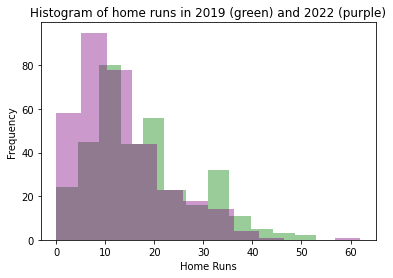

```python
plt.hist(set_2019.HR, bins = 12, color = "green", stacked = True, alpha = 0.4)
plt.hist(set_2022.HR, bins = 12, color = 'purple', stacked = True, alpha = 0.4)
plt.title("Histogram of home runs in 2019 (green) and 2022 (purple)")
plt.xlabel("Home Runs")
plt.ylabel("Frequency")
plt.show()
```

This next histogram is for hits in 2019 and 2022. While the two plots overlap a fair amount, it is worth noting the two spikes in the 2022 data that do not occur in the 2019 data. It is also worth noting that there is a much larger number of players that had 130+ hits in 2019 than there was in 2022.

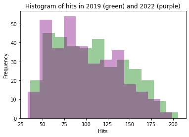

```python
plt.hist(set_2019.H, bins = 12, color = "green", stacked = True, alpha = 0.4)
plt.hist(set_2022.H, bins = 12, color = 'purple', stacked = True, alpha = 0.4)
plt.title("Histogram of hits in 2019 (green) and 2022 (purple)")
plt.xlabel("Hits")
plt.ylabel("Frequency")
plt.show()
```

This last histogram displays the strikeouts in 2019 and 2022. These two histograms are almost perfectly stacked on one another which shows that even though the number of hits and homeruns changed between these years, the strikeout tendencies didn't. This is important because it demonstrates that there wasn't a change in pitching between these two years or hitter tendencies, but rather a change in the baseball that was used.

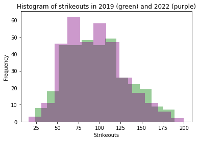

```python
plt.hist(set_2019.SO, bins = 12, color = "green", stacked = True, alpha = 0.4)
plt.hist(set_2022.SO, bins = 12, color = 'purple', stacked = True, alpha = 0.4)
plt.title("Histogram of strikeouts in 2019 (green) and 2022 (purple)")
plt.xlabel("Strikeouts")
plt.ylabel("Frequency")
plt.show()
```

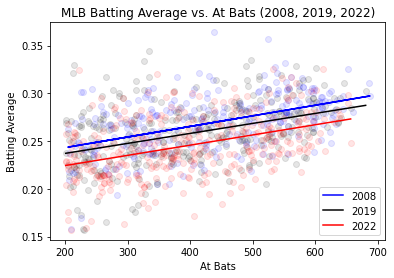

```python
#AB vs AVG 2008,2019, 2022

plt.scatter(set_2008.AB, set_2008.AVG, color = "blue", alpha = 0.1)
AVG_slope_2008, AVG_yint_2008 = np.polyfit(set_2008.AB, set_2008.AVG, 1)
plt.plot(set_2008.AB, AVG_slope_2008*set_2008.AB+AVG_yint_2008, color = "blue", label = "2008")

plt.scatter(set_2019.AB, set_2019.AVG, color = "black", alpha = 0.1)
AVG_slope_2019, AVG_yint_2019 = np.polyfit(set_2019.AB, set_2019.AVG, 1)
plt.plot(set_2019.AB, AVG_slope_2019*set_2019.AB+AVG_yint_2019, color = "black", label = "2019")

plt.scatter(set_2022.AB, set_2022.AVG, color = "red", alpha = 0.1)
AVG_slope_2022, AVG_yint_2022 = np.polyfit(set_2022.AB, set_2022.AVG, 1)
plt.plot(set_2022.AB, AVG_slope_2022*set_2022.AB+AVG_yint_2022, color = "red", label = "2022")

plt.xlabel("At Bats")
plt.ylabel("Batting Average")
plt.title("MLB Batting Average vs. At Bats (2008, 2019, 2022)")

plt.legend(loc = "lower right")
plt.show()
```

This next scatter plot displays the number of strikeouts against at bats. As was noted before, the 2019 and 2022 strikeout numbers are relatively similar. However, both of these strikeout statistics are much higher than what was seen in 2008.

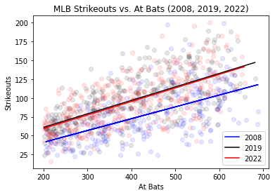

```python
#AB vs SO 2019, 2008, 2022

plt.scatter(set_2008.AB, set_2008.SO, color = "blue", alpha = 0.1)
SO_slope_2008, SO_yint_2008 = np.polyfit(set_2008.AB, set_2008.SO, 1)
plt.plot(set_2008.AB, SO_slope_2008*set_2008.AB+SO_yint_2008, color = "blue", label = "2008")

plt.scatter(set_2019.AB, set_2019.SO, color = "black", alpha = 0.1)
SO_slope_2019, SO_yint_2019 = np.polyfit(set_2019.AB, set_2019.SO, 1)
plt.plot(set_2019.AB, SO_slope_2019*set_2019.AB+SO_yint_2019, color = "black", label = "2019")

plt.scatter(set_2022.AB, set_2022.SO, color = "red", alpha = 0.1)
SO_slope_2022, SO_yint_2022 = np.polyfit(set_2022.AB, set_2022.SO, 1)
plt.plot(set_2022.AB, SO_slope_2022*set_2022.AB+SO_yint_2022, color = "red", label = "2022")

plt.xlabel("At Bats")
plt.ylabel("Strikeouts")
plt.title("MLB Strikeouts vs. At Bats (2008, 2019, 2022)")

plt.legend(loc = "lower right")
plt.show()
```

This scatter plot shows the home run changes over time. It is clear to see that there was a massive amount of home runs being hit in 2019 and then a sharp decrease to 2008 levels of home runs in 2022. Note also the outlier in the top right corner of the plot, Aaron Judge.

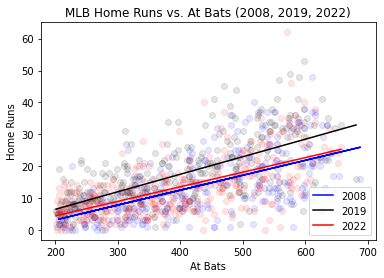

```python
#AB vs HR 2008, 2019, 2022

plt.scatter(set_2008.AB, set_2008.HR, color = "blue", alpha = 0.1)
HR_slope_2008, HR_yint_2008 = np.polyfit(set_2008.AB, set_2008.HR, 1)
plt.plot(set_2008.AB, HR_slope_2008*set_2008.AB+HR_yint_2008, color = "blue", label = "2008")

plt.scatter(set_2019.AB, set_2019.HR, color = "black", alpha = 0.1)
HR_slope_2019, HR_yint_2019 = np.polyfit(set_2019.AB, set_2019.HR, 1)
plt.plot(set_2019.AB, HR_slope_2019*set_2019.AB+HR_yint_2019, color = "black", label = "2019")

plt.scatter(set_2022.AB, set_2022.HR, color = "red", alpha = 0.1)
HR_slope_2022, HR_yint_2022 = np.polyfit(set_2022.AB, set_2022.HR, 1)
plt.plot(set_2022.AB, HR_slope_2022*set_2022.AB+HR_yint_2022, color = "red", label = "2022")

plt.xlabel("At Bats")
plt.ylabel("Home Runs")
plt.title("MLB Home Runs vs. At Bats (2008, 2019, 2022)")

plt.legend(loc = "lower right")
plt.show()
```

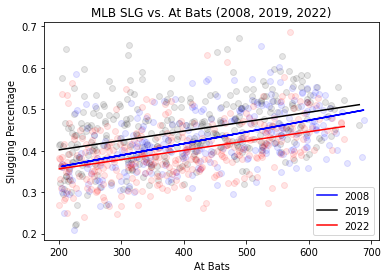

```python
#AB vs SLG 2008, 2019, 2022

plt.scatter(set_2008.AB, set_2008.SLG, color = "blue", alpha = 0.1)
SLG_slope_2008, SLG_yint_2008 = np.polyfit(set_2008.AB, set_2008.SLG, 1)
plt.plot(set_2008.AB, SLG_slope_2008*set_2008.AB+SLG_yint_2008, color = "blue", label = "2008")

plt.scatter(set_2019.AB, set_2019.SLG, color = "black", alpha = 0.1)
SLG_slope_2019, SLG_yint_2019 = np.polyfit(set_2019.AB, set_2019.SLG, 1)
plt.plot(set_2019.AB, SLG_slope_2019*set_2019.AB+SLG_yint_2019, color = "black", label = "2019")

plt.scatter(set_2022.AB, set_2022.SLG, color = "red", alpha = 0.1)
SLG_slope_2022, SLG_yint_2022 = np.polyfit(set_2022.AB, set_2022.SLG, 1)
plt.plot(set_2022.AB, SLG_slope_2022*set_2022.AB+SLG_yint_2022, color = "red", label = "2022")

plt.xlabel("At Bats")
plt.ylabel("Slugging Percentage")
plt.title("MLB SLG vs. At Bats (2008, 2019, 2022)")

plt.legend(loc = "lower right")
plt.show()
```

### Total Runs Bar Chart

This final plot is a bar chart that displays the total amount of runs scored in each of the years that were sureyed. 2019 has the highest total amount of runs scored and 2008 and 2022 have roughly the same amount of runs scored.

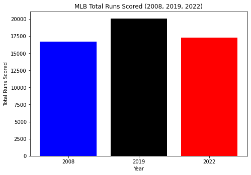

```python
# Number of Runs Barchart

fig = plt.figure()
ax = fig.add_axes([0,0,1,1])
years = ['2008', '2019', '2022']
total_runs = [sum(set_2008.R),sum(set_2019.R), sum(set_2022.R)]
ax.bar(years, total_runs, color = ["blue", "black", "red"])

plt.xlabel("Year")
plt.ylabel("Total Runs Scored")
plt.title("MLB Total Runs Scored (2008, 2019, 2022)")

plt.show()
```

## Conclusion

The era of gritty hitters who have quality at bats and minimal strikeouts is over. In modern baseball, managers want an team centered around big hitters who generate offense via home runs even if it costs them more strikeouts and a lower batting average. With his 2022 season, Aaron Judge has cemented himself as the posterboy of the modern hitter.

Although Aaron Judge had a great season, overall home runs in the MLB decreased significantly in 2022 as a result of the deadened baseball. How did he manage to have a great season despite the struggles of the rest of the league?

The surface answer is that he is a great hitter. However, what many people do not know is that on December 1st of the 2021 offseason the 20-year drug testing agreement between the MLB and the MLB Player's Association expired amid a controversial player lockout. It was not renewed until March 10th, 2022. This provided a three month window for any MLB player to take steroids without getting busted. Although Aaron Judge has never failed a drug test, it is suspicious that in the first season the MLB has had a lapse in steroid testing since 2002 a player put up a steroid era amount of home runs.

There is also a theory that some of the juiced baseballs used in the 2019 season showed up at yankees games that Aaron Judge played in, giving him an unfair advantage.

However, despite all of the controversy Aaron Judge is still a great hitter and deserves all the accolades for his record setting 62-home run season.